# Prosper Loan Exploration by Tat Cheong Chu

This report explores a dataset containing prices and attributes for approximately 113937 issued loan on the P2P platform Prosper.

# Univariate Plots Section

This is the data set which includes 81 variables and it’s impossible to investigate all of them. Before starting the detailed plotting section, I would like to categorize them into four main categories in order to understand the differences and relationships between each other. In order to highlight the variables mentioned, I would like to capitalize the first letters of variables in this report.

1. About reliability of borrowers
- Employment Status
- Employment Status Duration
- Occupation
- Home owner
- Stated Monthly Income
- Income Verifiable

These are the factors when we consider if a borrower is able to pay the loan or not. By intuition, someone who owns his own house and has a good job with high income should have the credit with more reputation.

2. valuation about Borrower
- Credit Grade
- Credit Score
- Prosper Rating
- Credit Score Range

Except Credit Lines, which only implicitly shows how mucg loan a borrower deserve to have, other variables are just using different ways, or different grading systems established by different organisations, to describe the reputation of the borrower in term of borrowing.

3. Credit charactoristic
- Borrower APR/RATE/Lender Yield
- Loan Original Amount
- Term
- investor

These variables describe how is the P2P-credit formed.

4. after the launch of Credit
- Revolving Account
- Loan Status
- Delinquencies Amount

These variables happen only after the the credit is issued.

These four categories are actually followed by the time of the launch of credit. From the formation of the personalty of borrowers, to the valuations for them, then the credit will be valued by the investors. At the end, the credit will be issued and the payment begins.

First of all, we start our Uni-variable Plots by following this time line.

## 1. About reliability of borrowers

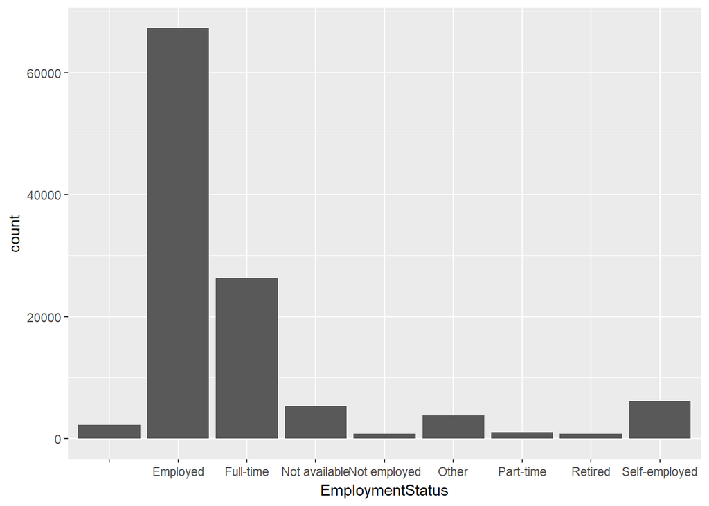

The majority of borrowers belong to the “Employed”, which is actually an ambiguous term and doesn’t tell us whether the borrowers are working on basis of “Part-time” or “Full-time”. And “self-employed” can be interpreted as a type of “employed”. But as least these four types of “employed” dominate the distribution of the employment status. These four types of people have a job and overwhelmingly represent the majority:

```
## [1] 0.8855683
```

What does it mean with the blank on the left-hand side? Did the borrowers miss filling the statement about their employment status? Let’s zoom this kind of “blank” status in:

```
##              Cancelled             Chargedoff              Completed
##                      3                    291                   1439
##                Current              Defaulted FinalPaymentInProgress
##                      0                    522                      0
##   Past Due (>120 days)   Past Due (1-15 days)  Past Due (16-30 days)
##                      0                      0                      0
##  Past Due (31-60 days)  Past Due (61-90 days) Past Due (91-120 days)
##                      0                      0                      0
```

The interesting thing is that none of these credits is current credit or past due. They are completed, or failures paying the credits in states of defaulted or charged-off, which are “ended” in some sense. This may not be a mere coincidence and later we can see that lots of our data come from current credit.

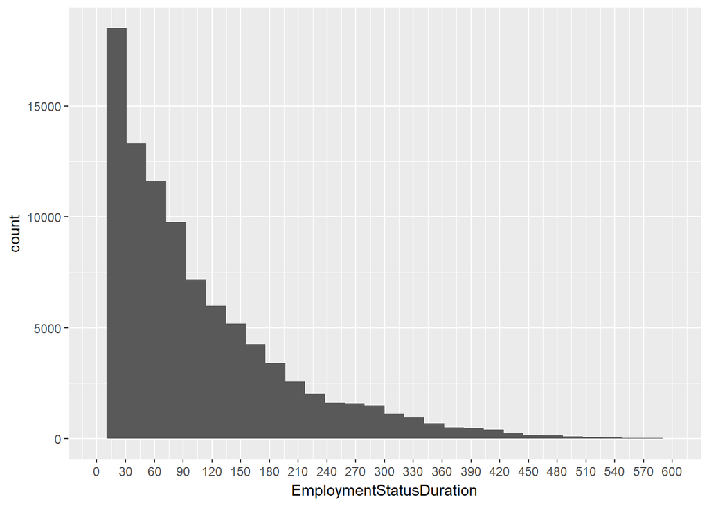

It is reasonable since it may also imply age distribution: the younger you are, the shorter you’ve worked. Obviously, P2P borrowing is relatively a new concept comparing to the traditional financial instruments, which should be recognized by more young people than elderly.

In order to show the graph in a form of normal distribution, we can sub the x variable into the log function.

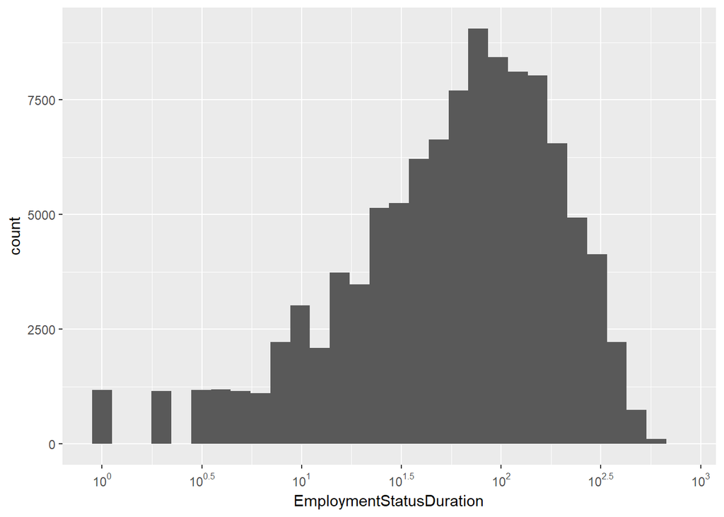

Although it shows us a normal distribution, but more data are lost during the process by removing more than 9100 rows of the data set. But it reminds me that even we don’t use the method of log function, we still need to remove more than 7000 rows since there is the majority of “NaN values”.

- Occupation

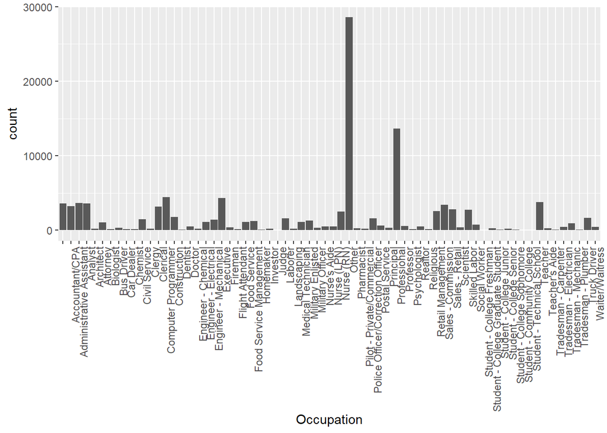

Again, there are ambiguous categories. This time, they are “Other” and “Professional” which don’t tell a specific name of the jobs. Like the section of “Employment Status”, lot of people intend to hide their private information. I wonder if these kinds of borrowers tend to hide the details of these two sections at the same time.

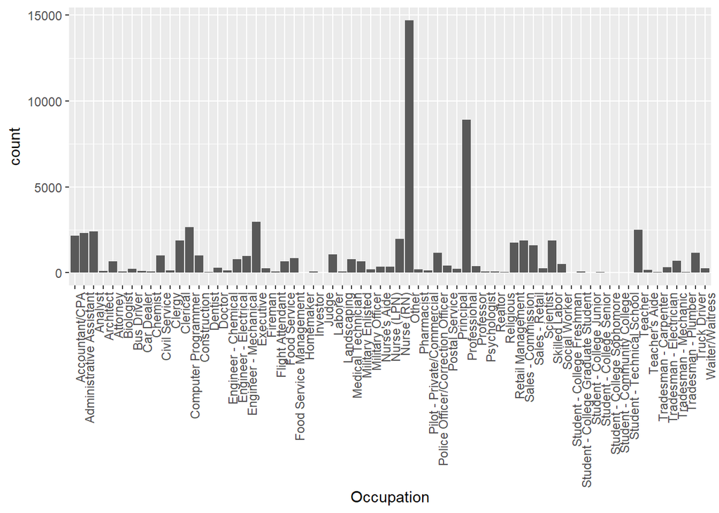

It seems that there are almost no differences between the distribution form. The second one is just like the mini-version of the first one with smaller amount on y-axis. Using ambiguous category may be not a important feature to consider.

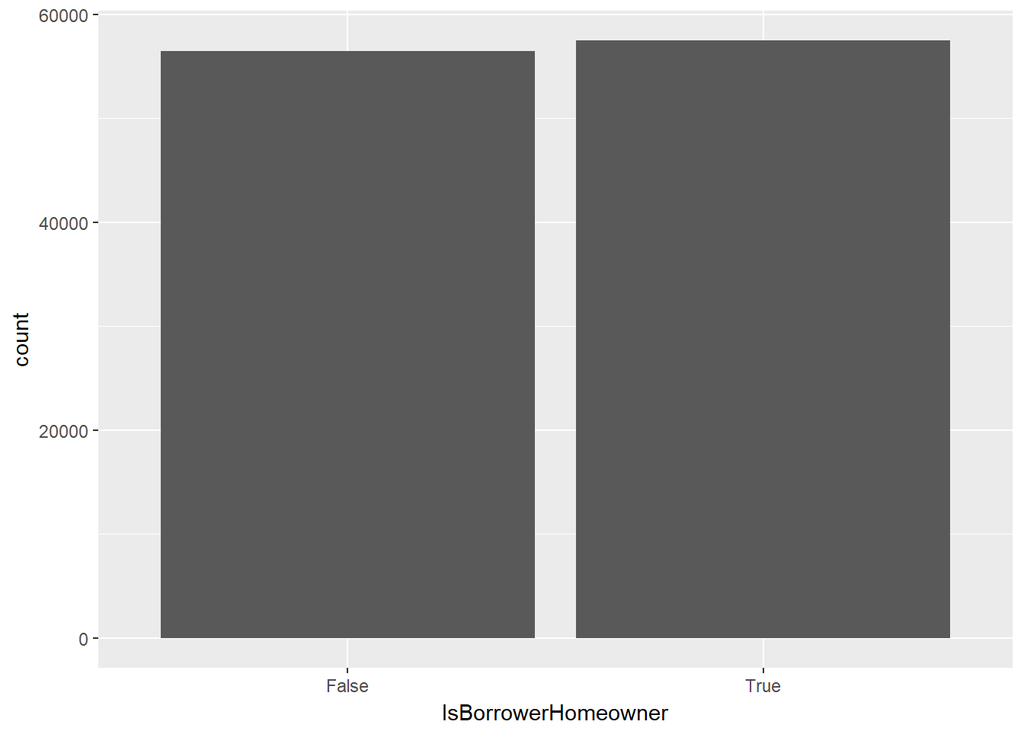

```
##
## False  True
## 56459 57478
```

The differences is about 1000 people, which is less than 1% of the objects in the whole data set.

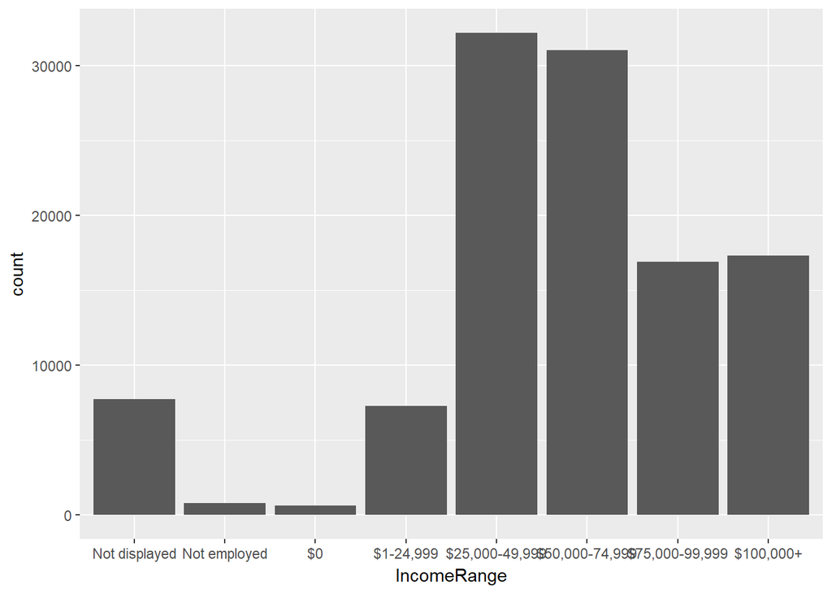

It seems like a reasonable distribution, because in most of the time, the distribution concentrates to the range of “$25,000-49,999” and “$50,000-74,999”, and actually it is the middle of the income range. And we should compare it to the stated monthly income in order to verify the data.

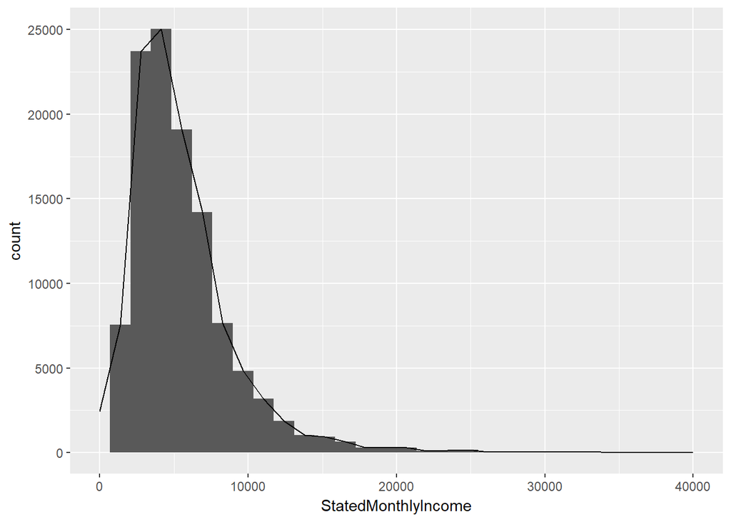

It has the similar form of slightly Skewed distribution, which needs the log function to become a normal distribution.

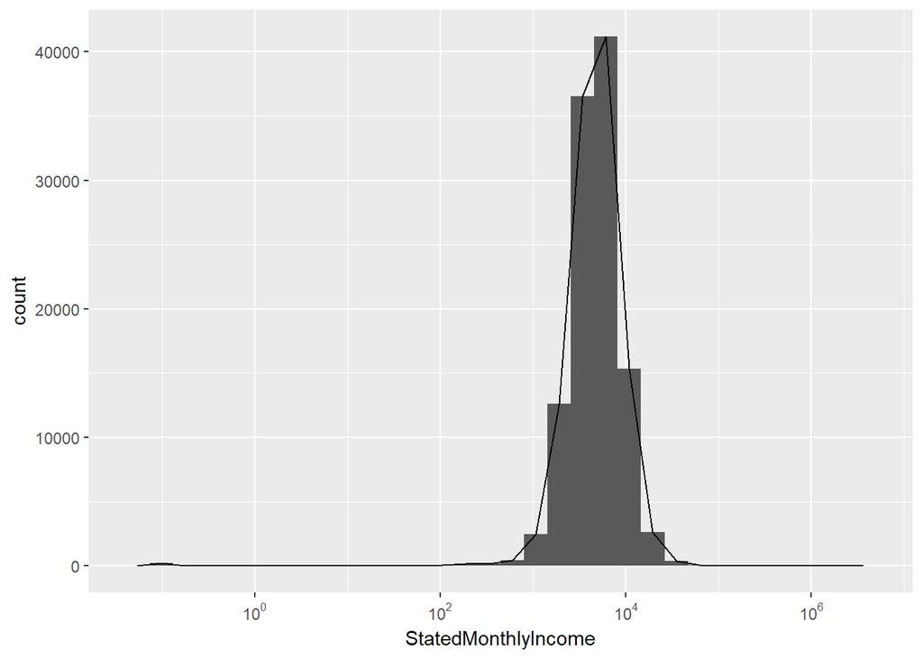

```
##    Min. 1st Qu.  Median    Mean 3rd Qu.    Max.
##       0    3200    4667    5608    6825 1750003
```

As we can see most of income amounts don’t reach the magnitude of 10^(4). As we can see in the summary, the mean of the data just reach 5608 or approximately 10^(3.74).

But is the data of income reliable? We can limit the data set with the variable of Income Verifiable.

```
##  False   True
##   8669 105268
```

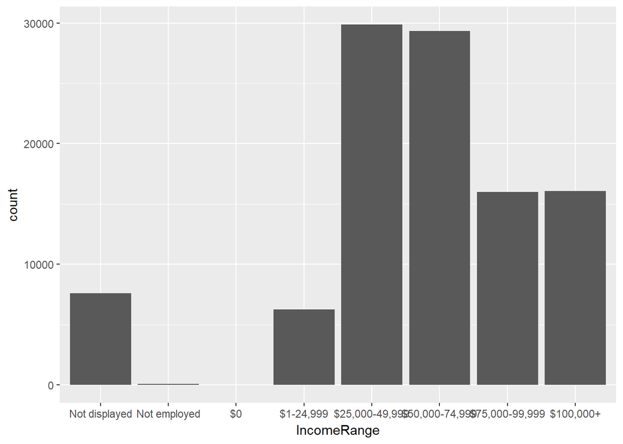

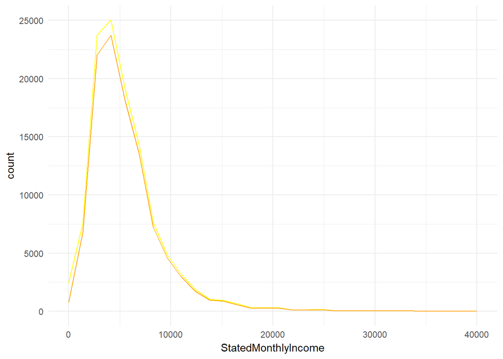

The first picture of our Income Range distribution has no obvious changes. The second picture shows the differences between the original and the one which excludes the unverified data. These two lines show the similar form. It means most of our data about income is trustable.

## 2. Valuation about Borrower

There are three different ways to describe the grading:

- Credit Grade
- Prosper Rating
- Credit Score Range

During my research, no evidence has been found to show that the credit score range in this data set come from the FICO score or Vantage score, which are two of the most famous credit grading, since the range doesn’t stay consistent to their standards. (https://www.creditsesame.com/blog/credit/credit-score-range-for-experian-transunion-equifax/, https://your.vantagescore.com/interpret_scores)

First of all, we need to make a subset including these variables or relative variables in order to examine them with a closer look.

The distribution of Credit Score Range Upper when the Credit Grade is equal to E:

```
##    Min. 1st Qu.  Median    Mean 3rd Qu.    Max.    NA's
##   559.0   579.0   579.0   581.4   599.0   599.0      71
```

When the Credit Grade is equal to D:

```
##    Min. 1st Qu.  Median    Mean 3rd Qu.    Max.    NA's
##   619.0   619.0   619.0   628.9   639.0   639.0      78
```

When the Credit Grade is equal to C:

```
##    Min. 1st Qu.  Median    Mean 3rd Qu.    Max.    NA's
##     659     659     659     667     679     679      98
```

Although we don’t know from what kind of institution the credit grade was issued, according to the common definition of credit grade, we know that the grade of E to A represents the credit reputation from bad to the better position. The only one which is worse than E is the grade of HR.

As we can see, the credit score range seems to relate to the credit grade, as the credit grade goes up, the range of credit score goes up as well.

But it is a different story when we examine the rating from Prosper:

When the Credit Grade is equal to E:

```
##    Min. 1st Qu.  Median    Mean 3rd Qu.    Max.
##   619.0   659.0   679.0   681.5   699.0   879.0
```

When the Credit Grade is equal to D:

```
##    Min. 1st Qu.  Median    Mean 3rd Qu.    Max.
##   619.0   679.0   699.0   699.3   719.0   879.0
```

When the Credit Grade is equal to C:

```
##    Min. 1st Qu.  Median    Mean 3rd Qu.    Max.
##   619.0   679.0   699.0   708.9   739.0   899.0
```

From the grade of E to C, they share the same minimum range of credit score. The maximum score of grade C is just a little bit higher than D and E.

We can examine the differences between these two systems of rating by using graphs:

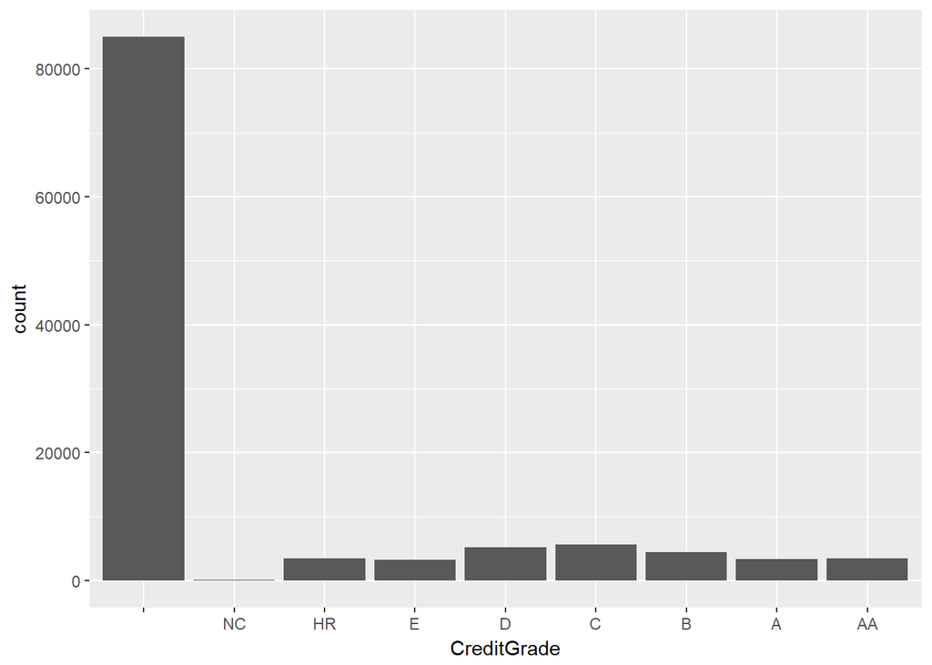

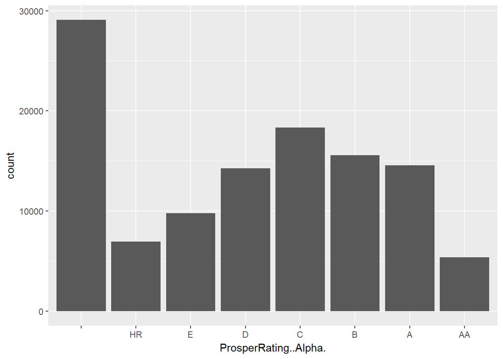

So why is the “Null value” also the largest part in these two graphs? It is found that all of the credit grade are only applied to the “ended” loan but never to the current loan.

```
##              Cancelled             Chargedoff              Completed
##                      5                   6650                  18288
##                Current              Defaulted FinalPaymentInProgress
##                      0                   4010                      0
##   Past Due (>120 days)   Past Due (1-15 days)  Past Due (16-30 days)
##                      0                      0                      0
##  Past Due (31-60 days)  Past Due (61-90 days) Past Due (91-120 days)
##                      0                      0                      0
```

At the first time, I thought that the credit grade was only applied to the “ended” credit. So it is reasonable to assume the Prosper rating only reveals the current credit. But: it isn’t. It includes all kinds of situation:

```
##              Cancelled             Chargedoff              Completed
##                      0                   5336                  19664
##                Current              Defaulted FinalPaymentInProgress
##                  56576                   1005                    205
##   Past Due (>120 days)   Past Due (1-15 days)  Past Due (16-30 days)
##                     16                    806                    265
##  Past Due (31-60 days)  Past Due (61-90 days) Past Due (91-120 days)
##                    363                    313                    304
```

And there is no a single row of data which consist two grading.

```
## [1] 0
```

*Any null lower score?*

```
## [1] 0
```

*Any null upper score?*

```
## [1] 0
```

That means we can have the whole picture of the data set via the credit score range:

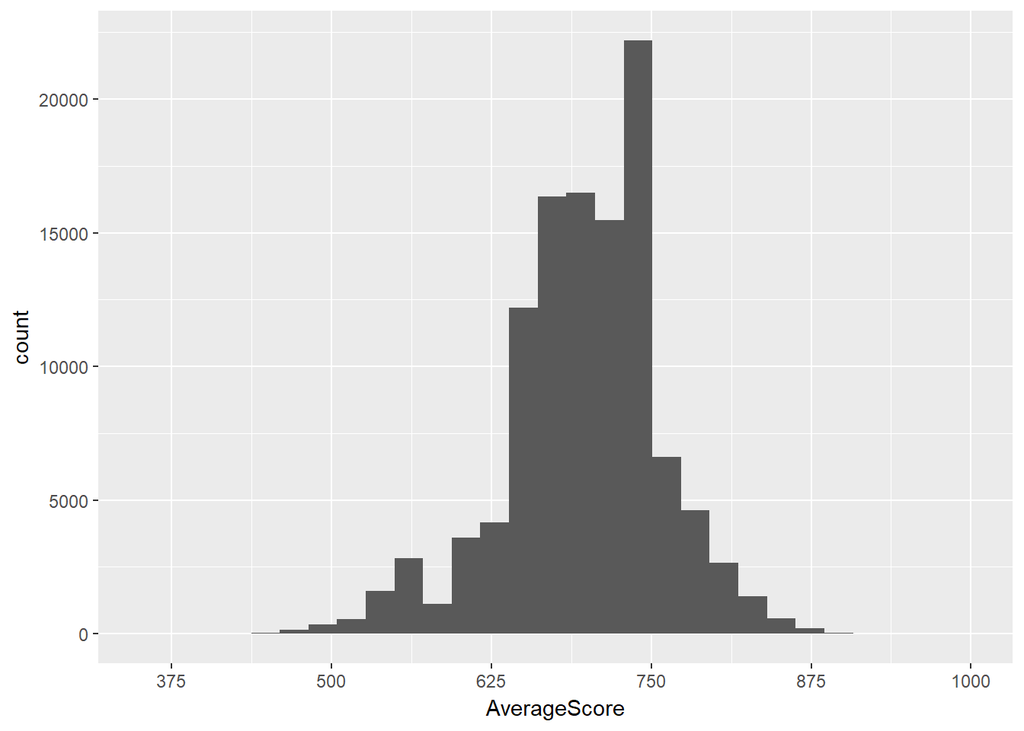

To conclude from these results:

Firstly, When we want to investigate the credit performance of all the borrowers, we can use average score of the score range. Although the source of the score is unknown, it covers all the data of borrowers.

In principle, the rating from Prosper is less believable because the rating is displayed on the homepage of the Prosper for investors to choose the products,which means the rating may not be accurate to represent the credibility of the borrowers, but may consider making some investment more attractive. We can investigate it in the Bi-variate Analysis section. (https://www.prosper.com/invest)

## 3. Credit charactoristic

- Borrower APR/RATE/Lender Yield

Actually these three variables describe the same thing on three different angles: interest rate.

The differences between Lender Yield and Borrower Rate is “a servicing fee charged by the originator to the investor each time a payment is made”.(https://www.orchardplatform.com/blog/2014519lender-yield-prosper/, it seems that it is using the same Prosper Data set as well.)

The “originator” here is Prosper.

Moreover, the borrowers need to pay the extra fee to the originator/Prosper. That is the differences between Borrower APR and Borrower Rate. The first one includes “other charges or fees such as mortgage insurance, most closing costs, discount points and loan origination fees.”(https://www.bankofamerica.com/mortgage/learn/apr-vs-interest-rate/)

So, the relationship between Borrower APR and Lender Yield should be like this:

Borrower APR = Lender Yield + extra fee paid by investors/lenders + extra fee paid by borrowers

So we can be sure that all the rate generally will move higher by following the order of “Lender Yield < Borrower Rate < Borrower APR”.

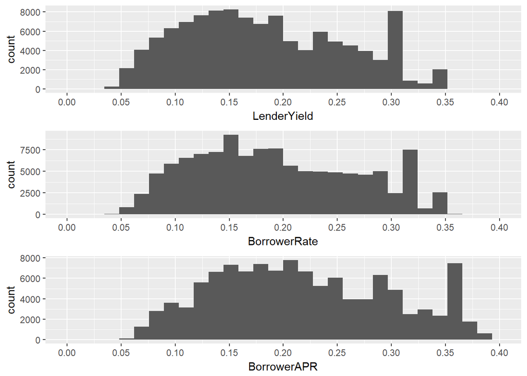

Both of the extra fees, are in most of the time “irregular” and depend on the the condition of investors and borrowers, so that we can see the form of three graphs have subtle differences on their distributions, but the trend of moving the bar towards the right hand side is still obvious, especially the “shift” happening on the graph of Borrower APR.

In order to gain a greater overview upon the interest, we can also put variables in the same graph.

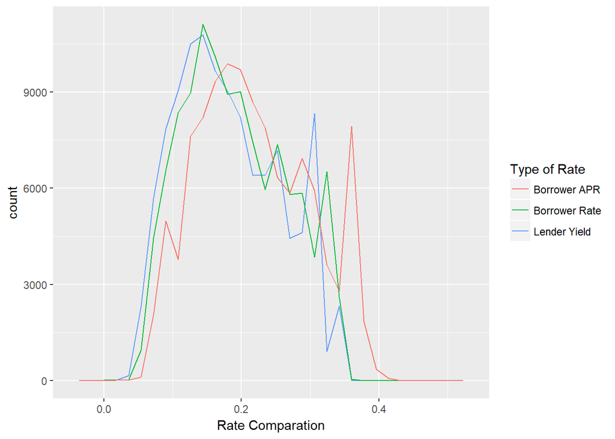

- Loan Original Amount

Next question is: how much have the borrowers borrowed?

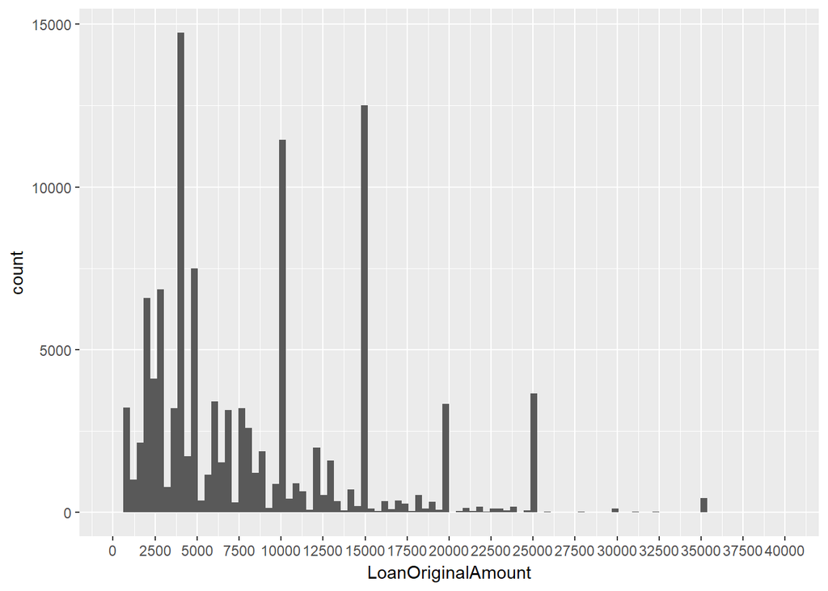

It is a different distribution than the interest rate which is calculated with the specific formula and weight. This one is chosen by the human borrowers and it is clear that some of amounts or numbers are popular among the others.

```
## # A tibble: 6 x 2
##   LoanOriginalAmount     n
##                <int> <int>
## 1               4000 14333
## 2              15000 12407
## 3              10000 11106
## 4               5000  6990
## 5               2000  6067
## 6               3000  5749
```

As we can see, borrowers raise their request with the simple whole numbers. It is quite understandable since borrowers don’t know how much they need to finance their businesses so exactly.

- Term

There are three types of term in the data set: 12, 36 and 60. The number actually represents the payment duration options provided by Prosper: in how many months a borrower need to pay back the credit or so-called a monthly loan payment.

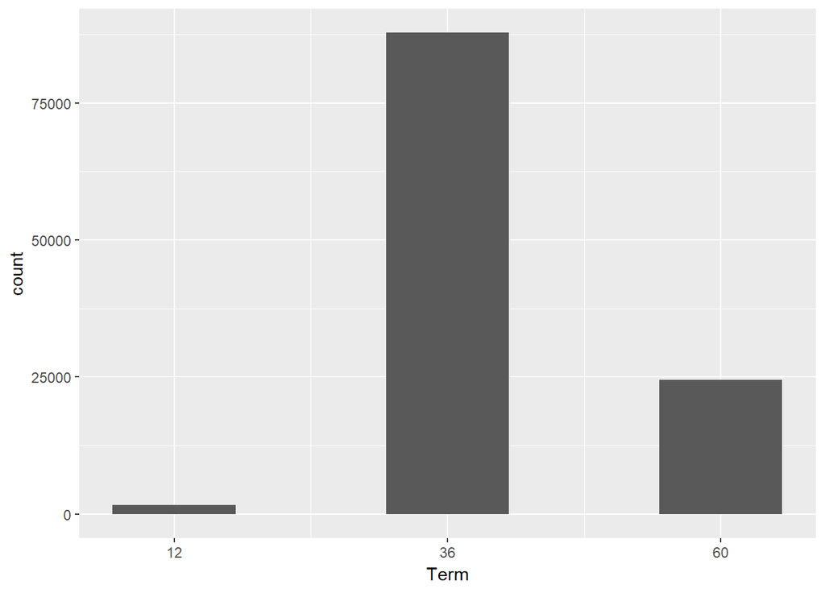

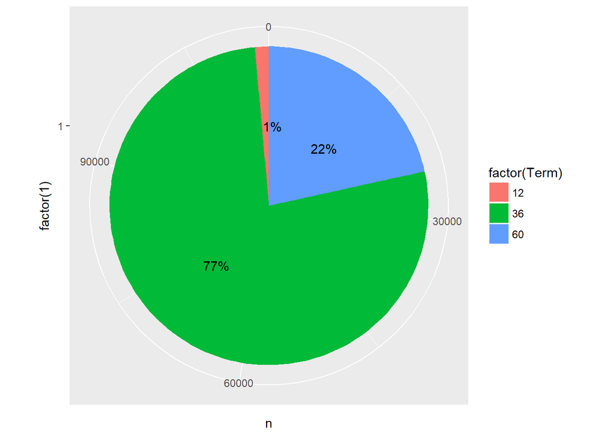

The preference of 3-year loan dominates the majority of the borrowers.

- investor

Investors or lenders lend the money to the borrowers on the platform of Prosper.

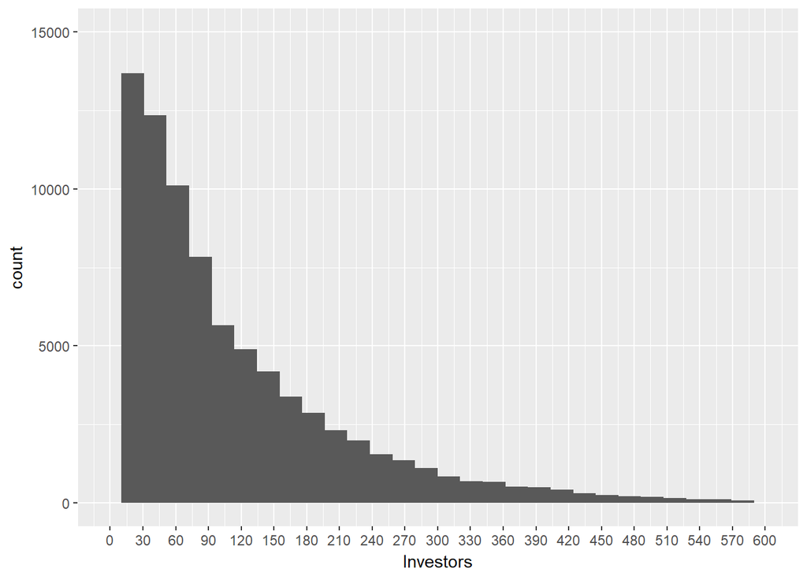

As we are having a uni-variable analyse, the changes of x axis/exogenous variable result in the y axis/endogenous variable. Here the endogenous variable shows how many credit are lended. The graph shows us a negative correlation. When the number of investors goes up, the number of credit goes down at the same time.

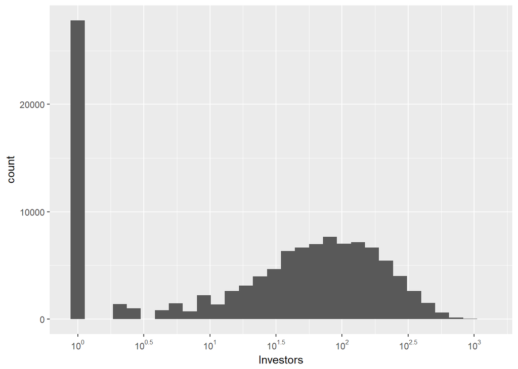

```
##    Min. 1st Qu.  Median    Mean 3rd Qu.    Max.
##    1.00    2.00   44.00   80.48  115.00 1189.00
```

As the summary shows, the mean is near to the level of 10^2, which forms the “pike” in the form of normal distribution.

The minimum number of the data set is only 1 and its first quarter is just 2. It is because there are lots of small amounts of investors in the data set.

So, how many borrower only gets one investor?

```
## [1] 0.2441174
```

Almost a quarter.

## 4. After the launch of Credit

- Revolving Account

According to the definition from Wikipedia, A revolving account is “an account created by a lender to represent debts where the outstanding balance does not have to be paid in full every month by the borrower to the lender.”(https://en.wikipedia.org/wiki/Revolving_account)

But it has its limitation and the borrowers should pay the principal and interest for what he owned in the following month.(http://blog.credit.com/2013/04/how-a-revolving-credit-account-works-65670/)

I have not heard of this term before, but to my own opinion, it creates an account to help the borrowers to delay their payment. It is an interesting payment strategy to avoid damaging the reputation or the credit grade of the borrower without paying on time.

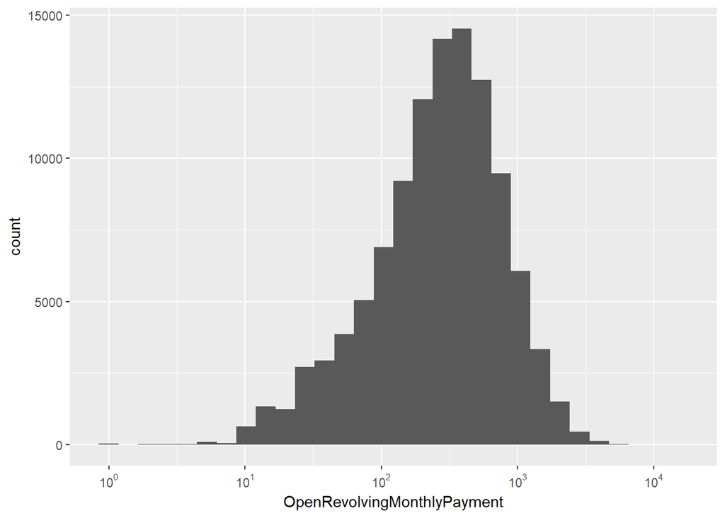

```
##    Min. 1st Qu.  Median    Mean 3rd Qu.    Max.
##     0.0   114.0   271.0   398.3   525.0 14985.0
```

People seem only afford a small amount of credit around 100 to 1000 in order to keep their record. So do most of them pay the credit on time? Let’s see the distribution of Loan Status.

- Loan Status

According to the definition from this website(https://www.orchardplatform.com/blog/understanding-loan-statuses/)shows us the different types of loan status:

++ Completed: fully paid off

++ Final Payment in Progress: move to the completed status within the next period

++ Current: making payments on time

++ Past Due: payment is missed

++ Charge Off: After 4 missed payments, the status of “current” will move to “charge-off”. In this situation, the investment is assumed to be lost.

++ Defaulted: reasons like bankruptcy make the borrowers fail to make the payment

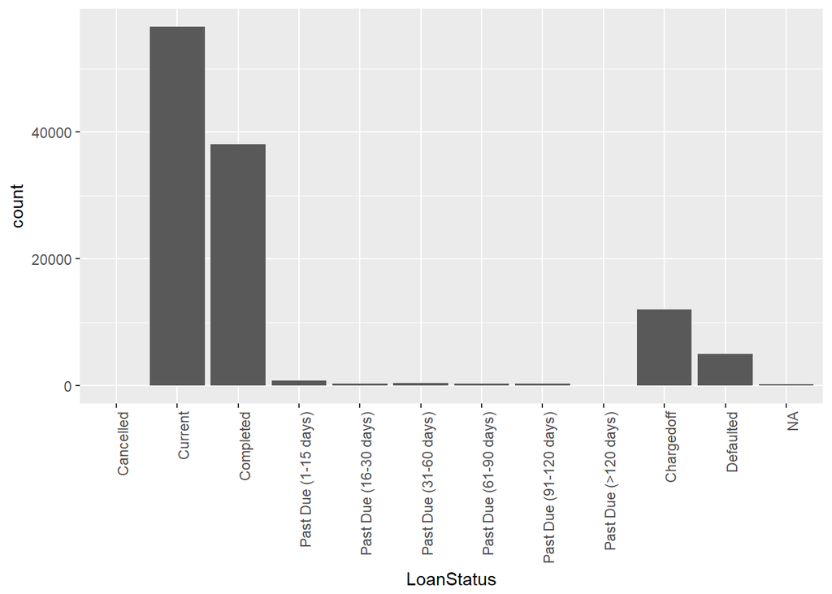

Most of the loans is either completed or current. But the category of “Past Due (>120 days)” makes me curious. According to the definition, the column of “Past Due (>120 days)” should not exist because Past Due which is longer than 120 days should be categorized as Charged-off. Some said it is more than 180 Days.(https://www.thebalance.com/deal-with-past-due-accounts-961128 / https://en.wikipedia.org/wiki/Charge-off)

```
## [1] 16
```

The number of “Past Due (>120 days)” is only 16, which is extremely small number comparing to the whole data set, so it is almost unobservable in the graph of Loan Status.

How about putting it in another way: maybe the borrowers with charge off may owe more money?

We have the variable of “Amount of Delinquencies” to investigate. Delinquent “is an individual or corporation with a contractual obligation to make payments against a loan in a timely manner, such as through a mortgage, but payments are not made on time.”(https://www.investopedia.com/terms/d/delinquent.asp)

How much is the amount of delinquency when the status is charged-off?

```
##    AmountDelinquent
## 18               NA
## 43               NA
## 58                0
## 63                0
## 75             5256
## 76                0
```

And How much is the amount of delinquency when the status is Past Due (91-120 days)?

```
##      AmountDelinquent
## 1115                0
## 1420                0
## 1438                0
## 1740                0
## 1797                0
## 1913                4
```

It is at most of time just…zero. Let’s try it with the current status:

```
##   AmountDelinquent
## 2                0
## 4            10056
## 5                0
## 6                0
## 7                0
## 8                0
```

There is one way to explain this phenomenon : we just see the label of loan status issued by Prosper during the period of payment. We have no idea how much and when the borrowers don’t pay back on time.

The “Current” status with non-zero amount of delinquency can be explained as well. Since the status is just a label issued by Prosper right on the date of the origination of the data set. Besides the status of “Complete”, many other labels can be moved to other categories as well. A Past-Due borrower may have the hope to move back to the “Current” status when he pay his money back on time again. But how does it happen? We may have no idea at all.

# Univariate Analysis

### What is the structure of your dataset?

There are 113,937 credit loans in the dataset with 81 features, most of the features can be divided into 4 group:

- About reliability of borrowers
- Valuation about Borrower
- Credit charactoristic
- After the launch of Credit

Other observations:

- Borrowers seem to reveal their own informations in the an ambiguous way.
- Borrowers prefer to pay the loan in term of 36, which is three-year.
- The majority of the loan in the data set is in the current status.

### What is/are the main feature(s) of interest in your dataset?

There are too many variables in the dataset, but by dividing them intogroups, we can simplify the logic we want to combine varables to build predictive models.

There are actually so many ways to do so because of the huge amounts of variables. I’d like to determine which feature predicts the number of investors. Because it’s the most important for the P2P platform to attract their investors in which kind of way.

Since we want to predict the consideration of investors, first of all we need to know what kinds of elements the investors will notice.

[figure not shown]

As the website of Prosper shows, there are some variables from our dataset can be found in the informations provided to the investors in the first place:

- Terms
- Credit Grade
- Loan originated Amount
- Lender Yield

I give up including variables of Estimated Effective Yield and Estimated Effective loss, althogh this may be the first impression provided to the lender as well. Firstly, I don’t understand the differences between Estimated Effective “Yield” and Estimated Effective “Return”. Sometimes they have the same rate, sometimes Estimated Effective Yield is equal to the sum of Estimated Loss and return. Secondly, there is no way to figure out which one is the term used by Prosper as “Estimated Effective Yield” in its website.

[figure not shown]

Thirdly, lots of completed credit have lost the record of Estimated Yield, Loss and Return

Lender Yield, as we have analyzed before, performs the similar distrubation like Borrower Rate and Borrower APR and always appear to be non-NaN value which allows us to analyse the dataset without excluding any data. We should be aware of the same situation happening in using Prosper Rating.

```
## [1] 84853
```

Other factors revealed in Prosper like

- the percentage of funded
- deadline of funding
- reasons of borrowing

are not avaliable in our dataset.

### What other features in the dataset do you think will help support your investigation into your feature(s) of interest?

Variables from the group of “About reliability of borrowers” affect the grading system, which generates the Prosper Rating to remind investors the level of risk.(https://www.prosper.com/plp/invest/prosper-ratings/) Variables like:

- Stated Monthly Income
- Employment Status

may be useful to our analyze.

Moreover, it will be interesting to compare the predictive performance of Credit Score Range with the Prosper Rating, since it is the factor which manipulates factors like Estimated Loss. Also it covers all the grading in the dataset and displays a complete picture of the dataset.

### Did you create any new variables from existing variables in the dataset?

Yes, I create new variables named “AverageScore” and “JobOwner”

The first one presents the variety of score range in a way of continuous data, which should be more convienient for us to analyze.

The second one helps us to simply distinguish whether the borrower is a job owner.

### Of the features you investigated, were there any unusual distributions? Did you perform any operations on the data to tidy, adjust, or change the form of the data? If so, why did you do this?

Yes. Some data need to be rescaled for a normal distribution, like the graph of Investors and monetary data like Stated Monthly Income, Loan Original Amount and Open Revolving Monthly Payment.

The distribution of the variable of investors is strange, even after the transformation of scale, because lots of loan only have one lender or investor.

Some labels of the variables need to be re-factorized, like Income Range, since there are orders between different income ranges.

# Bivariate Plots Section

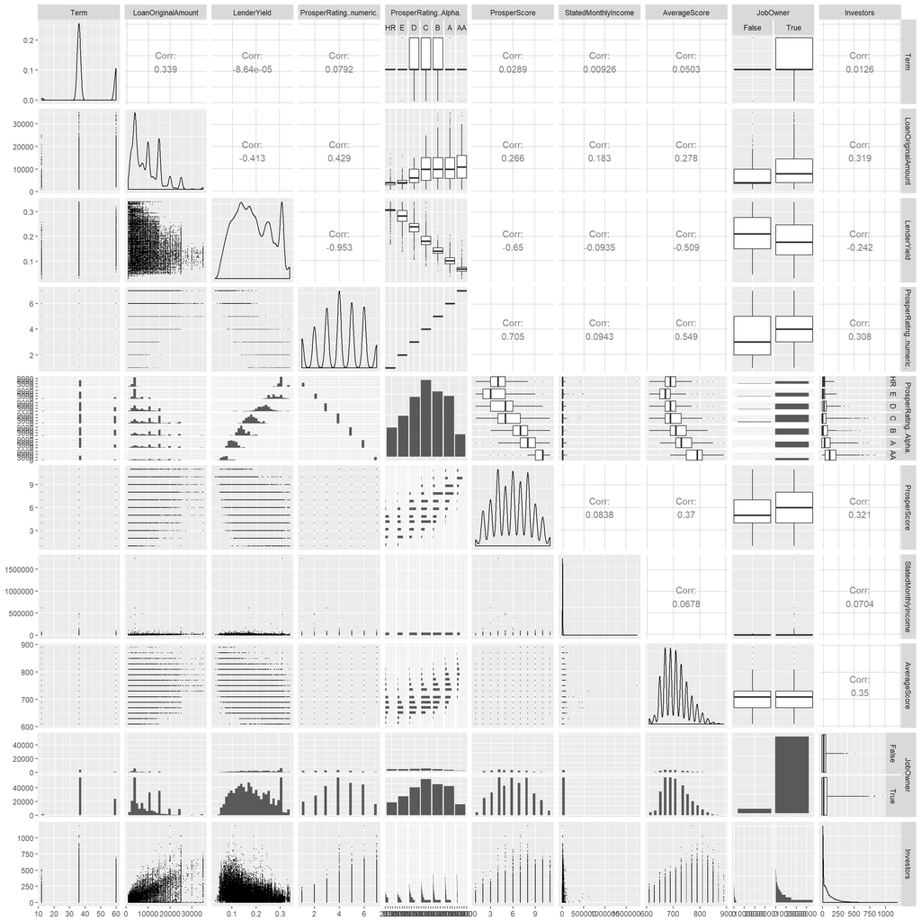

```
##                                  Term LoanOriginalAmount   LenderYield
## Term                     1.000000e+00          0.3391166 -8.636267e-05
## LoanOriginalAmount       3.391166e-01          1.0000000 -4.134223e-01
## LenderYield             -8.636267e-05         -0.4134223  1.000000e+00
## ProsperRating..numeric.  7.917914e-02          0.4285572 -9.531194e-01
## ProsperScore             2.894652e-02          0.2662933 -6.497835e-01
## StatedMonthlyIncome      9.257417e-03          0.1828698 -9.347742e-02
## AverageScore             5.031610e-02          0.2779185 -5.086950e-01
## Investors                1.255027e-02          0.3192348 -2.423262e-01
##                         ProsperRating..numeric. ProsperScore
## Term                                 0.07917914   0.02894652
## LoanOriginalAmount                   0.42855722   0.26629334
## LenderYield                         -0.95311937  -0.64978347
## ProsperRating..numeric.              1.00000000   0.70522142
## ProsperScore                         0.70522142   1.00000000
## StatedMonthlyIncome                  0.09430583   0.08375665
## AverageScore                         0.54887385   0.36960305
## Investors                            0.30775312   0.32059380
##                         StatedMonthlyIncome AverageScore   Investors
## Term                            0.009257417   0.05031610  0.01255027
## LoanOriginalAmount              0.182869787   0.27791847  0.31923475
## LenderYield                    -0.093477422  -0.50869500 -0.24232616
## ProsperRating..numeric.         0.094305830   0.54887385  0.30775312
## ProsperScore                    0.083756653   0.36960305  0.32059380
## StatedMonthlyIncome             1.000000000   0.06775664  0.07035118
## AverageScore                    0.067756642   1.00000000  0.34983670
## Investors                       0.070351182   0.34983670  1.00000000
```

From the scatter plot we can observe that it seems that the distributions of Terms and Job Owner don’t change a lot from their uni-variable form. So I decide not to examine them in this section.

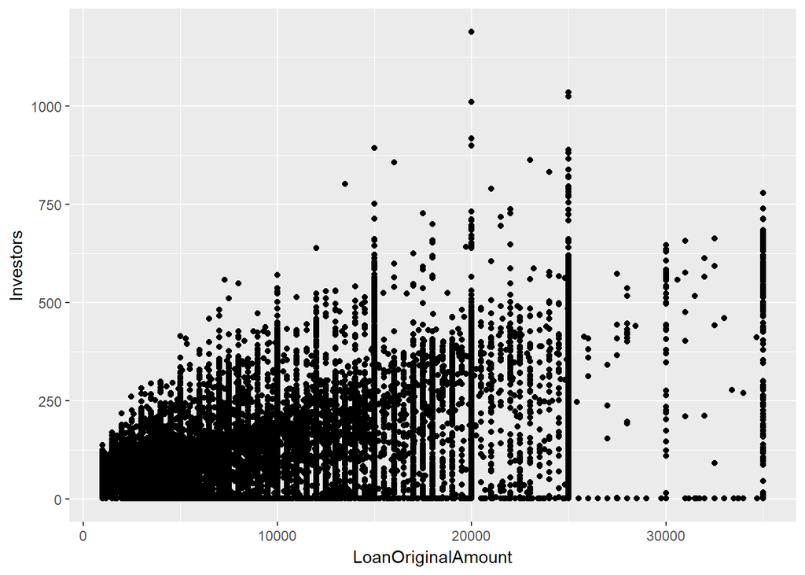

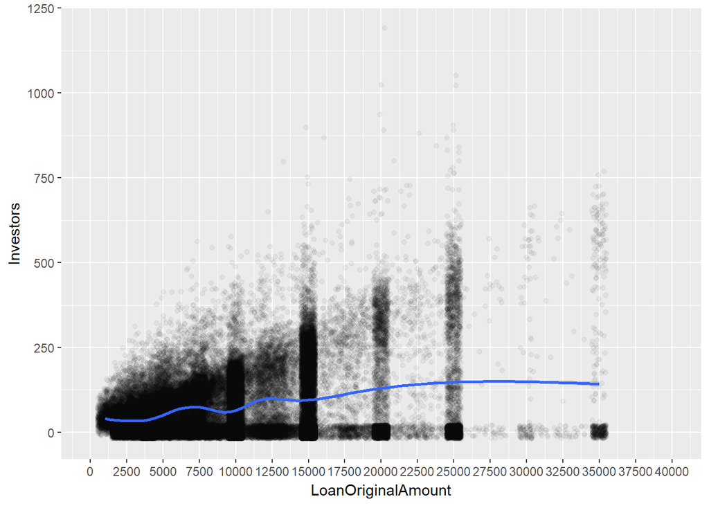

In our case study, it may mean that our investors prefer investing relative small amount of money and wait for the other investors rather than throwing lots of money to fulfill the amount requirement with small group of people.

Interesting thing is: the trend seems to stop after the amount of 25000.

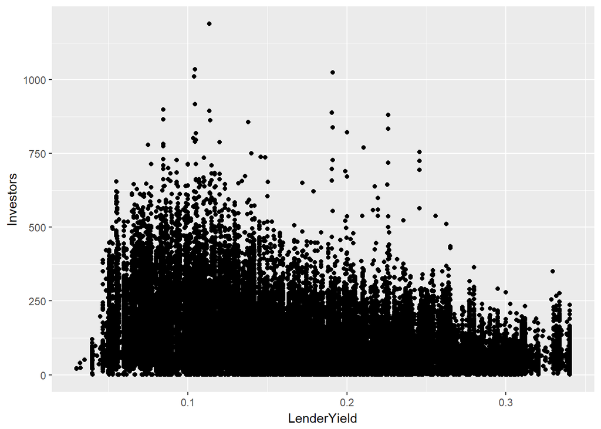

Again, we need the help of jitter and alpha.

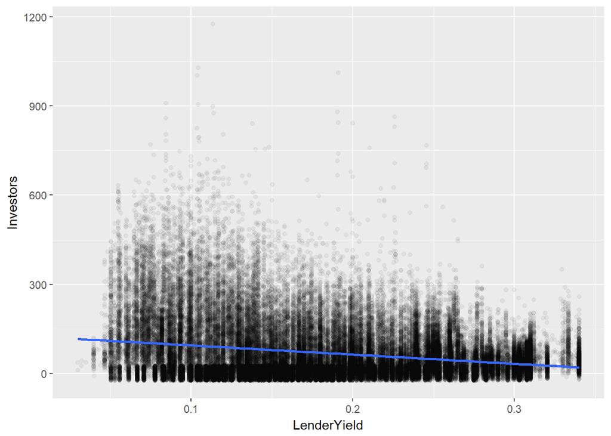

I think one reason of this is because the return is highly correlated with the risk. There is very high positive correlation between the Lender Yield and the Estimated Loss(although we have excluded lots of the data points in the following graph):

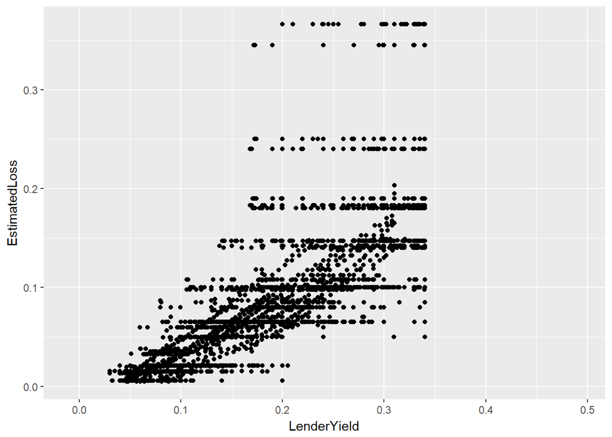

```
## [1] 0.9453084
```

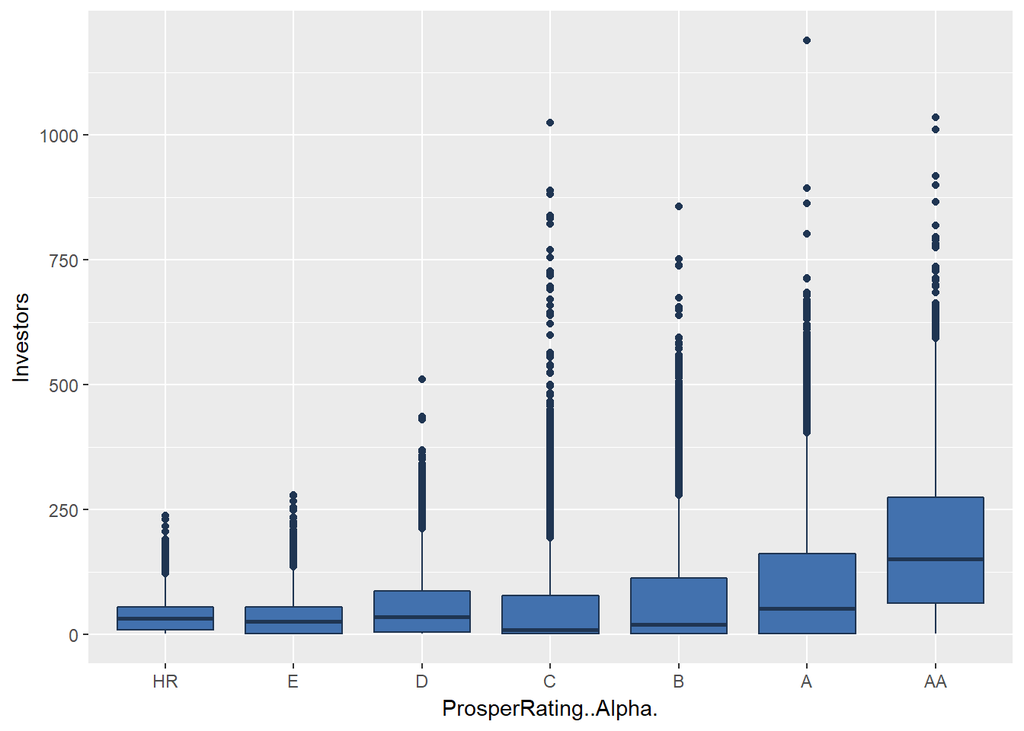

First of all, thanks for Jodie Burchell by refering his setting on colors and lines in this graph :(http://t-redactyl.io/blog/2016/04/creating-plots-in-r-using-ggplot2-part-10-boxplots.html)